# Open API and Shiny

Jong-June Jeon

May, 2018

## Open API

## API

- **A**plication **P**rogramming **I**nterface
- 핵심 기능을 외부 사이트에서 활용할 수 있도록 공개된 인터페이스
- 제공하는 사이트마다 제공 서비스마다 API의 형식이 다름
- 사이트 별, 서비스 별로 요구하는 변수를 제대로 입력해야 결과를 얻을 수 있음

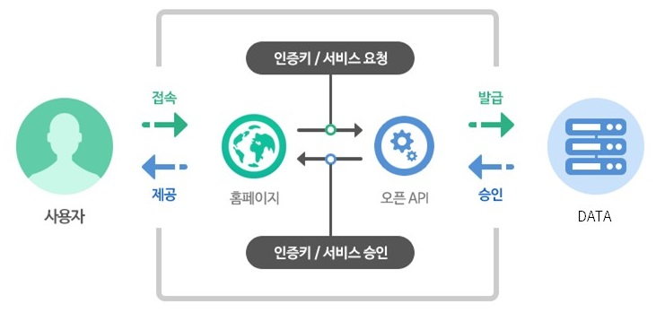

## Data collection example

- 서울시 공공데이터 포털:https://www.data.go.kr
- 공공데이터 포털의 미세먼지 데이터 API를 예시로 사용

[figure not shown]

- API 정보 확인 및 활용신청
- https://www.data.go.kr/dataset/15000581/openapi.do

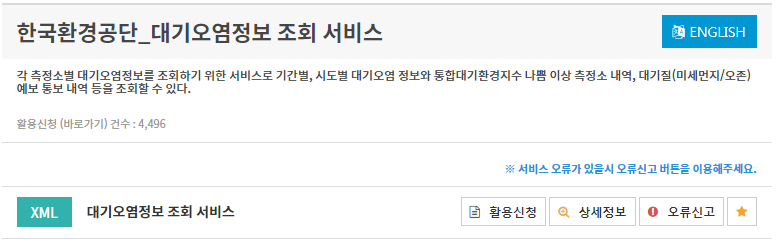

- 개발 목적에 맞게 개발 계정 신청
- 예시에서는 상세기능 "시군구별 실시간 평균정보 조회"을 사용
- 일반 인증키 발급을 통해 인증키 발급

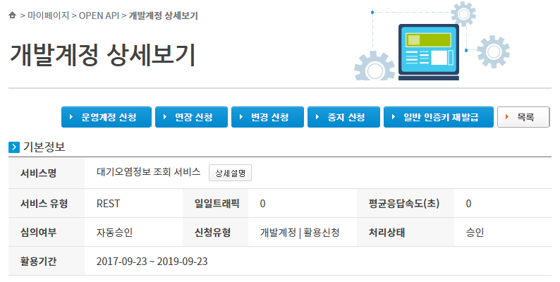

- 서비스정보에서 발급된 일반 인증키 확인 가능
- 참고문서를 통해 자세한 변수 및 기능 확인 가능

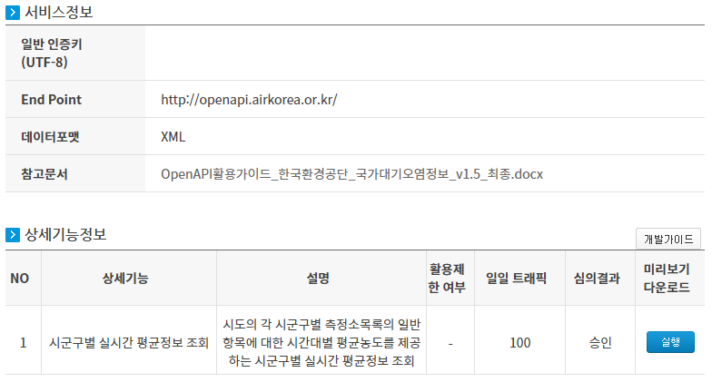

- "시군구별 실시간 평균정보 조회" 상세설명 확인
- 오퍼레이션명이 달라지면 다른 기능을 하는 구조
  - 예) 시도별 평균정보 조회를 원할 때 : getCtprvnMesureLIst
- 오퍼레이션명은 후에 서술할 URL 정보에 포함되어 있음

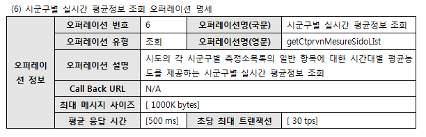

- "시군구별 실시간 평균정보 조회" 요청정보 확인
- 필요한 항목명에 대해 입력값을 넣어주면 입력값에 대한 결과를 출력
  - 예) numOfRows = 100 으로 주면 한 페이지에 100개의 결과를 출력

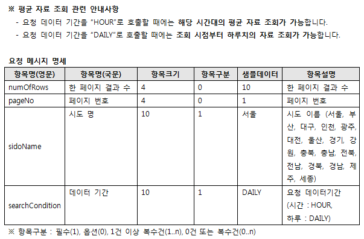

- "시군구별 실시간 평균정보 조회" 출력결과 정보 확인

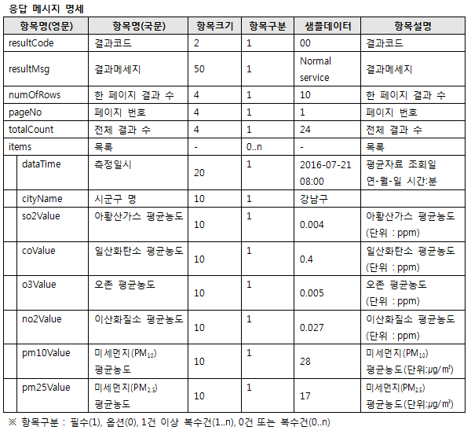

## R package

- 서울시 공공데이터 Api를 이용하기 위한 패키지 소개
1. httr 패키지
   - URL을 GET, POST 방식으로 호출하기 위해서 사용하는 패키지
   - 해당 API는 REST 방식으로 정보를 제공하므로 GET방식으로 URL을 호출
   - 사용할 함수
     1. GET()
2. rvest 패키지
   - 호출한 URL의 결과인 XML 형식에서 쉽게 데이터를 추출하기 위한 패키지
   - 사용할 함수
     1. read_xml()
     2. xml_nodes()
     3. xml_children()
     4. xml_text()
     5. xml_tag()

## Functions

1. GET()
   - 웹 페이지를 GET 방식으로 호출하여 결과를 저장
   - 웹 페이지의 header 혹은 요청 변수를 입력할 수 있음
   - POST 방식으로 작성된 페이지는 POST()를 이용하여 호출 가능
2. rvest
   - read_xml() : URL 혹은 GET으로 호출한 결과를 XML 형식으로 읽음
   - xml_nodes() : XML의 구조를 이용하여 해당 노드의 경로로 이동
   - xml_children() : 노드의 하위 구조를 출력
   - xml_text() : Tag 정보를 삭제하고 텍스트 결과만 출력
   - xml_tag() : Tag 정보를 출력

## Data collection

```r
rm(list = ls())
gc(reset = T)
```

```
##          used (Mb) gc trigger (Mb) max used (Mb)
## Ncells 488286 26.1     940480 50.3   488286 26.1
## Vcells 889139  6.8    1650153 12.6   889139  6.8
```

- 데이터 수집 전 메모리 정리 및 변수 제거

```r
if(!require(httr)){install.packages("httr"); library(httr)}
if(!require(rvest)){install.packages("rvest"); library(rvest)}
```

- 필요한 라이브러리 설치 및 호출

```r
service_key = "****"
```

- 발급된 서비스키을 service_key 변수에 할당

```r
url = paste0("http://openapi.airkorea.or.kr/openapi/services/rest/",
             "ArpltnInforInqireSvc/getCtprvnMesureSidoLIst?",
             "sidoName=서울",
             "&searchCondition=DAILY",
             "&pageNo=",1,
             "&numOfRows=",25,
             "&ServiceKey=",service_key)
```

- 요청 URL을 url 변수에 할당
- 예시에서는 서울 지역의 데이터 수집 코드 작성
- 서울에는 총 25개의 구가 있으므로 `numOfRows = 25`로 설정하여 데이터 요청
- 현재 시간에서 가장 가까운 `pageNo = 1` 시점의 데이터 요청

```r
if(!require(httr)){install.packages("httr"); library(httr)}

url_get = GET(url)
```

- URL을 GET방식으로 호출하여 데이터 요청

```r
if(!require(xml2)){install.packages("xml2"); library(xml2)}

url_xml = read_xml(url_get)
url_xml
```

```
## {xml_document}
## <response>
## [1] <header>\n  <resultCode>00</resultCode>\n  <resultMsg>NORMAL SERVICE ...
## [2] <body>\n  <items>\n    <item>\n      <dataTime>2018-04-29 11:00</dat ...
```

- 요청에 대한 출력값을 xml형식으로 읽어서 url_xml 변수에 할당
- url_xml 변수에는 위처럼 xml 형식으로 결과가 저장되어 있음

```r
if(!require(rvest)){install.packages("rvest"); library(rvest)}

item_list = xml_nodes(url_xml, 'items item')
```

- XML 형식으로 저장된 url_xml 변수에서 아래의 노드로 이동하여 필요한 데이터 수집

```r
item_list[[1]]
```

```
## {xml_node}
## <item>
## [1] <dataTime>2018-04-29 11:00</dataTime>
## [2] <cityName>강남구</cityName>
## [3] <so2Value>0.008</so2Value>
## [4] <coValue>0.5</coValue>
## [5] <o3Value>0.025</o3Value>
## [6] <no2Value>0.037</no2Value>
## [7] <pm10Value>41</pm10Value>
## [8] <pm25Value>21</pm25Value>
```

- item_list는 list형식의 데이터로 [[i]]에 하나의 구에대한 데이터가 포함되어 있음

```r
tmp_item = xml_children(item_list[[1]])
tmp_item
```

```
## {xml_nodeset (8)}
## [1] <dataTime>2018-04-29 11:00</dataTime>
## [2] <cityName>강남구</cityName>
## [3] <so2Value>0.008</so2Value>
## [4] <coValue>0.5</coValue>
## [5] <o3Value>0.025</o3Value>
## [6] <no2Value>0.037</no2Value>
## [7] <pm10Value>41</pm10Value>
## [8] <pm25Value>21</pm25Value>
```

- item_list의 1번인 강남구에 대해서 item_list에 있는 세부 변수 확인

```r
tmp_item = xml_text(tmp_item)
tmp_item
```

```
## [1] "2018-04-29 11:00" "강남구"           "0.008"
## [4] "0.5"              "0.025"            "0.037"
## [7] "41"               "21"
```

- 저장된 xml 형테의 세부 변수를 character 형식으로 변환하여 출력

```r
item_list = lapply(item_list, function(x) return(xml_text(xml_children(x))))
```

- 위의 과정을 모든 item_list에 동일하게 시행해야 하므로 lapply 함수 이용

```r
item_list[[1]]
```

```
## [1] "2018-04-29 11:00" "강남구"           "0.008"
## [4] "0.5"              "0.025"            "0.037"
## [7] "41"               "21"
```

```r
item_list[[2]]
```

```
## [1] "2018-04-29 11:00" "강동구"           "0.007"
## [4] "0.5"              "0.044"            "0.029"
## [7] "48"               "23"
```

- 각 [[i]] 마다 서울시의 구별 데이터가 정리됨을 확인할 수 있음

```r
item_dat = do.call('rbind',item_list)
item_dat = data.frame(item_dat, stringsAsFactors = F)
head(item_dat)
```

```
##                 X1     X2    X3  X4    X5    X6 X7 X8
## 1 2018-04-29 11:00 강남구 0.008 0.5 0.025 0.037 41 21
## 2 2018-04-29 11:00 강동구 0.007 0.5 0.044 0.029 48 23
## 3 2018-04-29 11:00 강북구 0.005 0.5 0.043 0.031 47 20
## 4 2018-04-29 11:00 강서구 0.009 0.4 0.059 0.028 43 19
## 5 2018-04-29 11:00 관악구 0.009 0.4 0.050 0.028 50 23
## 6 2018-04-29 11:00 광진구 0.008 0.8 0.039 0.031 47 17
```

- list 형태의 item_list를 data.frame 형태로 저장

```r
tmp = xml_nodes(url_xml, 'items item')
colnames_dat = html_name(xml_children(tmp[[1]]))
colnames_dat
```

```
## [1] "dataTime"  "cityName"  "so2Value"  "coValue"   "o3Value"   "no2Value"
## [7] "pm10Value" "pm25Value"
```

- 최종 데이터를 아래와 같이 생성가능

```r
colnames(item_dat) = colnames_dat
head(item_dat)
```

```
##           dataTime cityName so2Value coValue o3Value no2Value pm10Value
## 1 2018-04-29 11:00   강남구    0.008     0.5   0.025    0.037        41
## 2 2018-04-29 11:00   강동구    0.007     0.5   0.044    0.029        48
## 3 2018-04-29 11:00   강북구    0.005     0.5   0.043    0.031        47
## 4 2018-04-29 11:00   강서구    0.009     0.4   0.059    0.028        43
## 5 2018-04-29 11:00   관악구    0.009     0.4   0.050    0.028        50
## 6 2018-04-29 11:00   광진구    0.008     0.8   0.039    0.031        47
##   pm25Value
## 1        21
## 2        23
## 3        20
## 4        19
## 5        23
## 6        17
```

## Real-time data collection

- 미세먼지 데이터의 경우 1시간 간격으로 새로운 데이터 제공
- 이를 수집하기 위해서 1시간 간격으로 위의 과정을 반복하여 실시간으로 수집
- 반복문을 통해서 데이터를 생성하되 item_dat의 내용을 다른 변수에 축적하여 저장

```r
air_data = NULL
while(1)
{
  url = paste0("http://openapi.airkorea.or.kr/openapi/services/rest/",
               "ArpltnInforInqireSvc/getCtprvnMesureSidoLIst?",
               "sidoName=서울",
               "&searchCondition=DAILY",
               "&pageNo=",1,
               "&numOfRows=",600,
               "&ServiceKey=",service_key)
  url_xml = read_xml(GET(url))
  item_list = url_xml %>% xml_nodes('items item')
  item_list = lapply(item_list, function(x) return(xml_text(xml_children(x))))
  item_dat = do.call('rbind',item_list)
  item_dat = data.frame(item_dat, stringsAsFactors = F)
  names(item_dat) <- colnames_dat
  air_data = rbind(item_dat, air_data)
  Sys.sleep(3600)
  write.csv(air_data, "air_data.csv", row.names = F)
  cat(item_dat$dataTime[1],'\n')
}
```

## Yesterday's data collection

```r
air_data = NULL
for(i in 1:24)
{
  url = paste0("http://openapi.airkorea.or.kr/openapi/services/rest/",
             "ArpltnInforInqireSvc/getCtprvnMesureSidoLIst?",
             "sidoName=서울",
             "&searchCondition=DAILY",
             "&pageNo=",i,
             "&numOfRows=",25,
             "&ServiceKey=",service_key)
  url_xml = read_xml(GET(url))
  item_list = url_xml %>% xml_nodes('items item')
  item_list = lapply(item_list, function(x) return(xml_text(xml_children(x))))
  item_dat = do.call('rbind',item_list)
  item_dat = data.frame(item_dat, stringsAsFactors = F)
  air_data = rbind(item_dat, air_data)
}
```

## Shiny

## Welcome to Shiny

- Shiny는 R의 패키지
- Shiny를 통해 iterative한 웹사이트를 구현할 수 있음
- Shiny : https://shiny.rstudio.com/에서 다양한 예제 제공

## Introduction

- Shiny 의 구동

  shiny는 shinyApp() 함수를 통해 구동된다. shinyApp() 는 arguement 로 ui 객체와 server 함수를 기본적으로 요구한다.
  1. ui
     - 웹페이지의 앞쪽을 구성
     - 다시 말해서, 웹페이지에서 보이는 부분을 구성
     - 웹 개발 분야의 프론트엔드(Front END)와 유사
  2. server
     - 웹페이지에서 필요한 연산을 구성
     - ui를 통한 사용자의 요청에 대한 결과값을 다시 ui로 전달
     - 웹 개발 분야의 백엔드(Back END)와 유사

## Example of Shiny programming : ui

- ui를 통해 웹페이지의 보이는 부분을 구성
- 페이지를 구성하는 함수는 매우 다양하며 이 문서에서는 그 중 일부를 사용
- 사용할 페이지 구성 함수
  1. fluidPage()
  2. titlePanel()
  3. sidebarLayout()
  4. sidebarPanel()
  5. mainPanle()
- Server에 전달할 값을 입력할 수 있는 input 중 일부를 사용
- 사용할 입력 함수
  1. textInput()
  2. selectInput()
  3. numericInput()
  4. checkboxInput()
- Server에 전달받은 값을 출력할 수 있는 output 중 일부를 사용
- 사용할 출력 함수
  1. textOutput()
  2. plotOutput()

## Example of Shiny programming : server

- server를 통해 웹페이지에서 필요한 연산을 구성
- 연산에 필요한 함수는 다양하며 그 중 일부를 사용
  1. reactive()
  2. renterText()
  3. renterPlot()

## Example 1

- Shiny를 통해 Text를 입력하면 같은 Text를 출력하는 웹페이지를 생성
- 아래의 그림과 같은 Layout과 Title을 사용

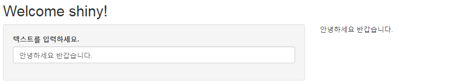

## Example 1 : ui

```r
library(shiny)

ui = fluidPage(
  titlePanel("Welcome shiny!"),
  sidebarLayout(
    sidebarPanel(
      textInput("input_text", "텍스트를 입력하세요.")
    ),
    mainPanel(
      textOutput("output_text")
    )
  )
)
```

- shiny::fluidPage() 함수를 통해 전체 페이지를 구성한다.
  - fluidPage 는 페이지 안에 포함되는 여러 element를 지정한다.
  - 여기서는 페이지 안에 있는 element로 titlePanel, slidebarLayout를 지정하였다.
  - 참고로 fluidPage 함수에 theme 옵션을 사용하면 CSS 파일을 지정하여, 원하는 테마를 결과물인 html 페이지에 적용할 수 있다.

## Example 1 : ui

- titlePanel() 함수를 통해 페이지의 제목을 설정
  - 옵션으로 windowTitle이 있다.
- sidebarLayout() 함수는 Sidebar와 메인 영역을 생성한다.
  - sidebarPanel() arguement 로 sidebarPanel과 mainPanel, position이 있다.
  - sidebarPanel에는 입력값을 받을 수 있는 sidebarPanel을 입력하고, mainPanle에는 출력물을 포함한 mainPanel을 입력하는 곳이다.
  - 여기서는 sidebar에 textInput(), mainpanel에 textOutput() 함수를 통해 데이터의 입출력을 설정하였다.

## Example 1 : ui

- sidebarPenel()
  - 옵션으로 width 가 있어 sidebar의 크기를 조정해 줄 수 있다.
- textInput()
  - textInput(inputId, label, value = "", width = NULL, placeholder = NULL) 로 사용한다.
    - inputId: input slot의 식별자로 여기에 입력한 텍스트로 textInput에 입력한 값으로 접근할 수 있다.
    - label: 라벨
    - value: 처음에 입력된 값
    - 입력칸의 넓이: 100px, 200% 와 같이 사용한다.
  - textOutput

## Example 1 : server function

```r
server = function(input, output)
{
  return(NULL)
}
```

- input과 output 을 argument 로 받으며, R프로그래밍을 이용한 계산과정에 대한 코드를 여기에 작성하여야 한다.
- server 함수의 input은 list의 형태로 값을 저장하며, ui 에서 input 관련 함수들을 통해 입력된 list 열의 이름("inputId")와 그에 대응하는 값(value 혹은 입력된 값)을 이미 가지고 있다.
- server 함수의 output 값은 ui에서 output으로 지정한 "ouputId" 를 리스트 열의 이름으로 할당 해 놓았으며, 대응되는 값은 비어있는 상태다.
- server 함수에서 input과 관련한 여러가지 계산을 통해서 output list의 값을 채워 넣는다.
- server가 아무것도 출력하지 않는다면 ui에 아무것도 출력되지 않는다.

## Example 1 : server function

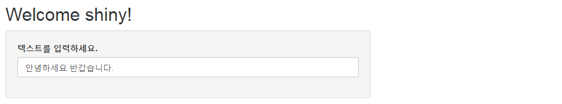

## Example 1 : server

```r
server = function(input, output)
{
  output$output_text = renderText({
    input$input_text
  })
}
```

- ui에서 입력한 input_text 변수는 input$`inputId` 즉, input$input_text 에 저장
- server에서 input$input_text에 저장된 값을 output$`inputId` 즉, output$output_text에 할당. 단, renderText 함수를 이용해서 문자열이 입력될때 마나 값이 반영되도록 하였음.
- mainPanle에 textOutput 함수에서 output_text를 선언해 놓았으므로 output$output_text 의 값은 ui에서 textOutput의 위치에 출력
- 위의 두 변수를 아래와 같이 ShinyApp을 통해 실행하면 결과를 확인할 수 있음

```r
shinyApp(ui = ui, server= server)
```

## Example 2

- R 기본 내장 데이터인 iris 데이터를 이용
- iris 데이터의 연속형 변수들을 K-means clustering을 이용한 군집화
- 군집된 각 데이터를 시각화 하는 웹페이지 구성
  1. X 변수, Y 변수를 선택하여 평면에 산점도를 출력
  2. 각 점은 Cluster에 따라서 다른 색으로 표현
  3. 군집의 중심을 입력하면 볼 수 있도록 함수 구성

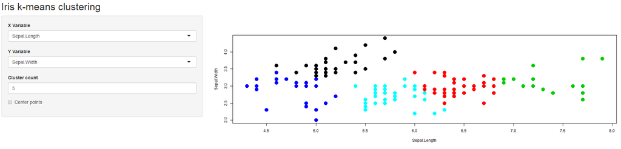

## Example 2 : ui

```r
ui = fluidPage(
  headerPanel('Iris k-means clustering'),
  sidebarPanel(
    selectInput('xcol', 'X Variable', names(iris)),
    selectInput('ycol', 'Y Variable', names(iris),
                selected=names(iris)[[2]]),
    numericInput('clusters', 'Cluster count', 3,
                 min = 1, max = 9),
    checkboxInput('center_tf','Center points')
  ),
  mainPanel(
    plotOutput('plot1')
  )
)
```

## Example 2 : ui

- Example 1과 마찬가지로 ui 구성
- sidebarPanel에 총 네개의 Input을 입력하도록 구성
  1. selectInput('변수명','표기명','가능한 선택지')
  2. numericInput('변수명','표기명','초기값',…)
  3. checkboxInput('변수명','표기명')
- mainPanel에 출력 plot을 구성
  1. plotOutput()

## Example 2 : ui

- server가 아무것도 출력하지 않도록 설정하여 ui의 구성을 확인할 수 있음

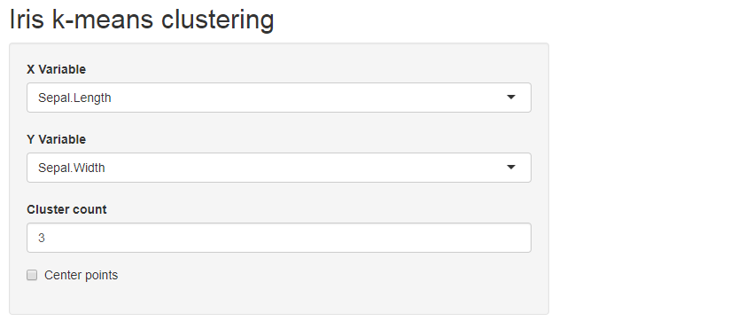

```r
server = function(input, output)
{
  return(NULL)
}
shinyApp(ui = ui, server = server)
```

## Example 2 : server

- server에서 처리해야할 객체를 확인해 보자
  - xcol
  - ycol
  - clusters
  - center_tf

## Example 2 : server

```r
server = function(input, output)
{
  selectedData = reactive({
    iris[, c(input$xcol, input$ycol)]
  })
  clusters <- reactive({
    kmeans(selectedData(), input$clusters)
  })

  output$plot1 <- renderPlot({
    plot(selectedData(),
         col = clusters()$cluster,
         pch = 20, cex = 3)
    if(input$center_tf) points(clusters()$centers, pch = 4, cex = 4, lwd = 4)
  })
}
```

## Example 2 : server

- ui에서 선택한 xcol, ycol변수는 각각 input$xcol, input$ycol에 저장됨
- 추출된 두 iris데이터는 reactive() 함수를 이용하여 selectedData에 할당
- reactive()
  1. 함수를 통해 사용자가 선택한 변수를 실시간으로 반영
  2. selectedData는 xcol과 ycol의 함수로 생각할 수 있음
  3. reactive로 저장된 변수는 함수처럼 사용됨을 확인
- clusters 변수에도 마찬가지로 reactive를 이용하여 kmeans의 결과를 할당
- output$plot1에 추출된 데이터의 산점도를 출력
  1. 추출된 iris 두 열의 산점도를 plot을 이용하여 그림
  2. 각 데이터의 색상은 kmeans 함수의 결과인 cluster를 이용하여 변경
- checkboxInput이 체크되면 kmeans 함수의 결과인 centers를 산점도에 출력
- shinyApp에 저장된 변수인 ui, server를 입력하여 웹페이지를 생성

```r
shinyApp(ui = ui, server= server)
```

## Shiny web page using fine dust data

## Data collection

- Shiny 예제를 위한 데이터 수집
- 25개 구의 24시간의 데이터 총 600개의 데이터를 수집

```r
url = paste0("http://openapi.airkorea.or.kr/openapi/services/rest/",
           "ArpltnInforInqireSvc/getCtprvnMesureSidoLIst?",
           "sidoName=서울",
           "&searchCondition=DAILY",
           "&pageNo=",1,
           "&numOfRows=",600,
           "&ServiceKey=",service_key)
url_xml = xml(GET(url))
item_list = url_xml %>% xml_nodes('items item')
item_list = lapply(item_list, function(x) return(xml_text(xml_children(x))))
item_dat = do.call('rbind',item_list)
item_dat = data.frame(item_dat, stringsAsFactors = F)
item_dat[item_dat == '-'] = 0
tmp = xml_nodes(url_xml, 'items item')
colnames_dat = xml_tag(xml_children(tmp[[1]]))
colnames(item_dat) = colnames_dat
```

- 데이터 중 '-'로 표기된 데이터를 0으로 처리
- 각 구의 위치 정보를 얻기 위해서 ggmap 패키지 호출
- ggmap패키지의 geocode()를 이용한 구별 위경도 수집

```r
library(ggmap)
uniq_region = unique(item_dat$cityName)
geo_dat = geocode(paste("서울특별시", uniq_region))
geo_dat = cbind(cityName = uniq_region, geo_dat)
head(geo_dat)
```

```
##   cityName      lon      lat
## 1   강남구 127.0473 37.51724
## 2   강동구 127.1238 37.53013
## 3   강북구 127.0257 37.63961
## 4   강서구 126.8495 37.55098
## 5   관악구 126.9516 37.47841
## 6   광진구 127.0823 37.53848
```

- 기존에 수집한 item_dat와 geo_dat를 merge
- merge한 데이터를 'air_quality.csv' 파일로 저장

```r
item_dat = merge(item_dat, geo_dat, by = "cityName")
head(item_dat)
write.csv(item_dat, 'air_quality.csv', row.names = F)
```

```r
dat = read.csv('air_quality.csv', stringsAsFactors = F)
head(dat)
```

```
##   cityName         dataTime so2Value coValue o3Value no2Value pm10Value
## 1   강남구 2017-09-25 10:00    0.005     0.6   0.012    0.035        45
## 2   강남구 2017-09-24 13:00    0.005     0.5   0.036    0.021        53
## 3   강남구 2017-09-24 20:00    0.005     0.5   0.049    0.018        71
## 4   강남구 2017-09-24 21:00    0.005     0.5   0.049    0.014        78
## 5   강남구 2017-09-25 05:00    0.004     0.4   0.014    0.022        40
## 6   강남구 2017-09-24 22:00    0.005     0.4   0.042    0.014        35
##   pm25Value      lon      lat
## 1        34 127.0473 37.51724
## 2        36 127.0473 37.51724
## 3        55 127.0473 37.51724
## 4        62 127.0473 37.51724
## 5        27 127.0473 37.51724
## 6        24 127.0473 37.51724
```

## Example 1

- API를 이용하여 수집한 서울시의 미세먼지 데이터를 활용한 웹페이지 생성
- 시간별, 지역별, 미세먼지 종류별로 히스토그램을 생성하여 출력

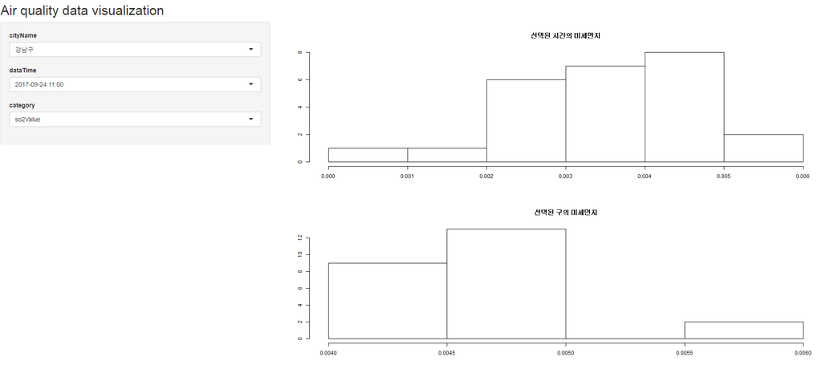

## Example 1 : ui

```r
ui = fluidPage(
  titlePanel("Air quality data visualization"),
  sidebarLayout(
    sidebarPanel(
      selectInput('region', 'cityName', choices = sort(unique(dat$cityName))),
      selectInput('date', 'dataTime', choices = sort(unique(dat$dataTime))),
      selectInput('category', 'category', choices = colnames(dat)[3:8])
    ),
    mainPanel(
      plotOutput("hist1"),
      plotOutput("hist2")
    )
  )
)
```

- 페이지의 Title을 titlePanel로 생성
- sidebarLayout 사용
- 미세먼지 데이터의 cityName, dataTime, 미세먼지 종류를 server로 전달
- 서버에서 두개의 히스토그램을 ui로 전달하여 mainPanel에 출력
- 각각의 히스토그램을 hist1, hist2의 변수명으로 저장

```r
server = function(input, output)
{
  return(NULL)
}
shinyApp(ui = ui, server = server)
```

- 빈 server를 만들어서 ui 확인

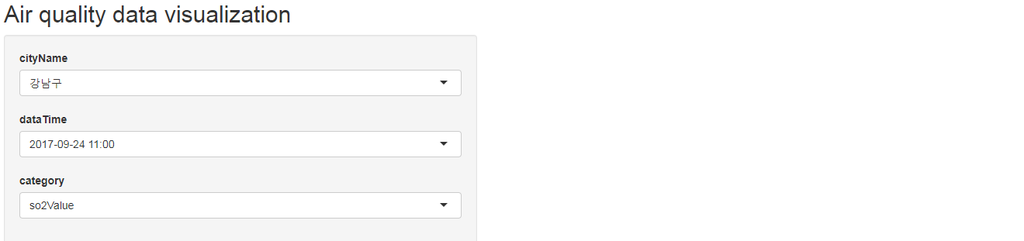

## Example 1 : server

```r
server = function(input, output)
{
  selectedData1 = reactive({
    dat[dat$dataTime == input$date, c(input$category)]
  })
  selectedData2 = reactive({
    dat[dat$cityName == input$region, c(input$category)]
  })
  output$hist1 = renderPlot({
    hist(selectedData1(), main = "선택된 시간의 미세먼지", xlab = "", ylab = "")
  })
  output$hist2 = renderPlot({
    hist(selectedData2(), main = "선택된 구의 미세먼지", xlab = "", ylab = "")
  })
}
```

- selectedData1에 선택된 시간의 미세먼지 데이터를 할당
  - ui에서 input한 dateTime과 일치하는 행을 추출
  - ui에서 input한 미세먼지 종류와 일치하는 열을 추출
- selectedData2에 선택된 구의 미세먼지 데이터를 할당
  - ui에서 input한 region과 일치하는 행을 추출
  - ui에서 input한 미세먼지 종류와 일치하는 열을 추출
- 저장된 selectedData1, 2의 데이터로 히스토그램 생성
- 생성한 히스토그램은 각각 hist1, hist2에 저장
- output은 다시 ui로 hist1, hist2를 전달하여 ui에 히스토그램을 생성

```r
shinyApp(ui = ui, server = server)
```

- shinyApp으로 저장된 변수 ui, server 이용하여 웹페이지 생성

## Example 2

- 미세먼지 데이터의 위 경도 좌표를 활용한 시각화
- 시간별, 미세먼지 종류별로 지도 위에 밀집도를 시각화하는 웹페이지 작성
- 지도에 density의 밀도를 조절할 수 있는 sliderInput 구성

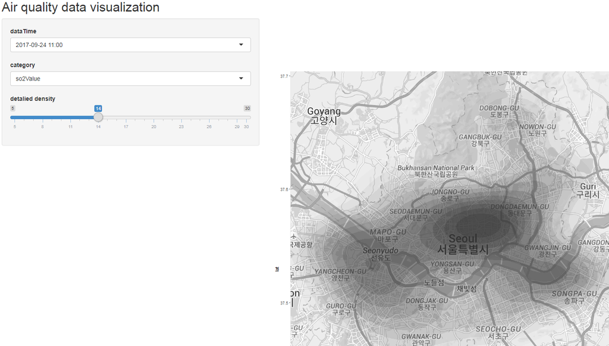

## Example 2 : ui

```r
ui = fluidPage(
  titlePanel("Air quality data visualization"),
  sidebarLayout(
    sidebarPanel(
      selectInput('date', 'dataTime', choices = sort(unique(dat$dataTime))),
      selectInput('category', 'category', choices = colnames(dat)[3:8]),
      sliderInput('bins', 'detalied density', min = 5, max = 30, value = 10)
    ),
    mainPanel(
      plotOutput("mapplot"),
      tableOutput("tt")
    )
  )
)
```

- ui는 Example 1과 유사하게 구성
- server로 입력하는 값에 bins 변수를 추가하여 density의 크기를 조절

```r
server = function(input, output)
{
  return(NULL)
}
shinyApp(ui = ui, server = server)
```

- 빈 server함수를 통해 ui 확인

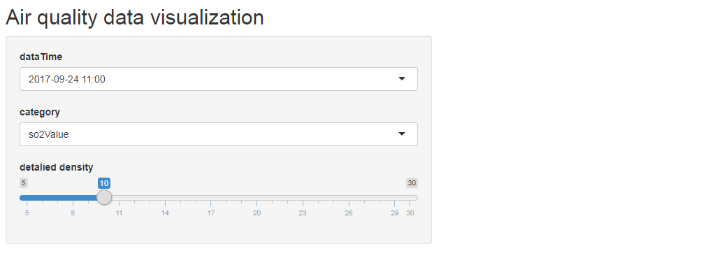

## Example 2 : server

```r
library(ggmap)
server = function(input, output)
{
  map_dat = reactive({
    tmp_dat = dat[dat$dataTime == input$date, c(input$category, "lon", "lat")]

    values = tmp_dat[,c(input$category)]
    min_value = min(values[values != 0])
    values = values / min_value
    tmp_dat[,c(input$category)] = values
    with(tmp_dat, tmp_dat[rep(1:nrow(tmp_dat), tmp_dat[,c(input$category)]),])
  })
  map = ggmap(get_googlemap(center = c(lon = 127.02, lat = 37.53),
                            zoom = 11,
                            maptype = "roadmap",
                            color = "bw"))
  output$mapplot = renderPlot({
    map  + stat_density2d(aes(x = lon, y = lat, alpha = ..level..),
                     data = map_dat(),
                     size= 2,
                     bins= input$bins,
                     geom="polygon") +
    scale_alpha(range = c(0, 0.3))
  }, height = 1200, width = 1024)
}
```

- 전체 server함수는 위의 구조로 이루어져 있음

## Example 2 : server (1)

- 전체 서버구조를 3개로 나누어서 소개

```r
 map_dat = reactive({
    tmp_dat = dat[dat$dataTime == input$date, c(input$category, "lon", "lat")]

    values = tmp_dat[,c(input$category)]
    min_value = min(values[values != 0])
    values = values / min_value
    tmp_dat[,c(input$category)] = values
    with(tmp_dat, tmp_dat[rep(1:nrow(tmp_dat), tmp_dat[,c(input$category)]),])
  })
```

- ui에서 입력한 input 값을 통해 데이터를 추출
  1. 입력한 시간이 dataTime과 일치하는 데이터를 추출
  2. 확인하고자 하는 미세먼지 데이터와 위 경도 데이터를 추출
- 추출된 데이터를 시각화에 편리하도록 정제
  1. 미세먼지 데이터는 그 크기가 다양하여 같은 weight를 주기 어려움
  2. 추출된 미세먼지 column에서 0을 제외한 최소값을 계산
  3. 각 구별 데이터를 최소값으로 나누어 미세먼지 데이터를 비율로 변경

```r
with(tmp_dat, tmp_dat[rep(1:nrow(tmp_dat), tmp_dat[,c(input$category)]),])
```

- reactive 객체를 통해서 위의 값을 출력
- plot을 그리기 위해서 미세먼지 데이터의 비율을 가중치로 사용
- 데이터의 최소값에 대한 비율만큼 데이터를 반복하여 가중치 생성

## Example 2 : server (2)

- 지도 데이터를 가져오기 위해 ggmap패키지 호출

[figure not shown]

```r
library(ggmap)
map = ggmap(get_googlemap(center = c(lon = 127.02, lat = 37.53), zoom = 11,
                            maptype = "roadmap",
                            color = "bw"))
map
```

## Example 2 : server (3)

```r
library(ggplot2)
output$mapplot = renderPlot({
    map  + stat_density2d(aes(x = lon, y = lat, alpha = ..level..),
                     data = map_dat(),
                     size= 2,
                     bins= input$bins,
                     geom="polygon") +
    scale_alpha(range = c(0, 0.3))
  }, height = 1200, width = 1024)
```

- ggmap 을 이용한 map에 ggplot2 패키지의 함수들을 이용하여 시각화
- 생성된 map_dat()와 input에 입력된 bins는 stat_density2d()의 변수로 사용
- renderPlot의 크기를 height와 width를 이용하여 지정

```r
shinyApp(ui = ui, server = server)
```

- shinyApp을 이용하여 웹페이지 생성

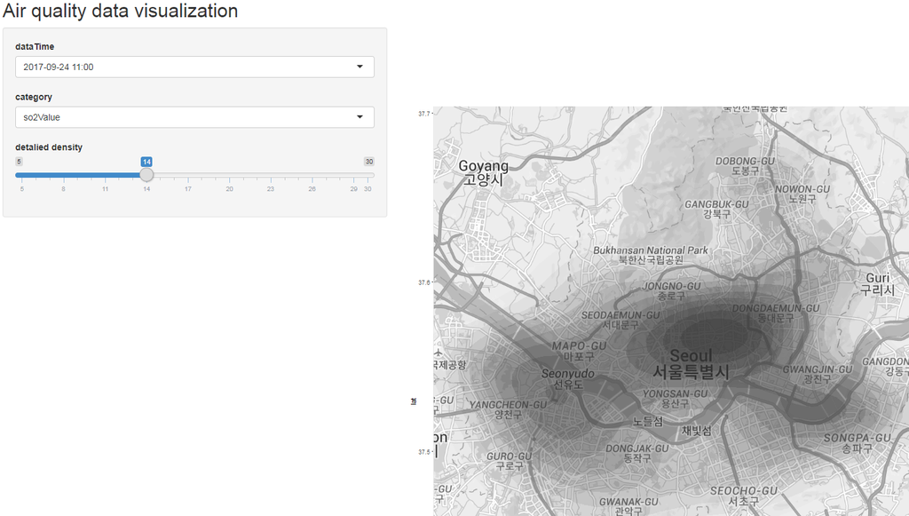

## R shiny server

## server 컴퓨터의 운용

- linux 계열의 서버 컴퓨터 준비
  - pc에 리눅스 os 설치 후 고정 ip 설정
    - 아마존 웹서비스(EC2)에 OS 설치
      - https://opentutorials.org/course/2717
- OS 포트설정
  - https://www.r-bloggers.com/shiny-server-on-aws/
    - 기본적으로 shiny는 http 프로토콜에 3838 포트를 사용한다.

## server 컴퓨터의 운용

- OS에 R, Rstudio, shiny-server 및 Rmarkdown의 설치
  - https://www.digitalocean.com/community/tutorials/how-to-set-up-shiny-server-on-ubuntu-14-04
- App 제작
  - /srv/shiny-server/ 내에 폴더를 생성하고 ui.R 과 server.R을 넣어둔다.
  - 홈페이지에 3838포트로 ui.R 과 server.R가 저장된 폴더에 url 링크를 걸어두면, shiny 페이지를 볼 수 있다.